# SR_03_RLTD_ORG_PTR_ADDR_ZIP

Related organization zip · Identifier report

## Overview

**Description**

Address Foreign - Postal code

**Table**

`SR-P03-T01-ID-RLTD-ORGS-TAXABLE-PARTNERSHIP` (many)

**Location code**

`SCHED-R-PART-03-COL-A`

**Family**

`SCHED-R-PART-03-COL-A` · siblings: SR_03_RLTD_ORG_PTR_ADDR_CITY, SR_03_RLTD_ORG_PTR_ADDR_CNTR, SR_03_RLTD_ORG_PTR_ADDR_L1, SR_03_RLTD_ORG_PTR_ADDR_L2, SR_03_RLTD_ORG_PTR_ADDR_STATE, SR_03_RLTD_ORG_PTR_EIN

**Data type**

text (xsd: TextType, ZIPCodeType)

**Scope**

PC

**Status**

unreviewed

6

xpaths mapped (6 observed)

145,922

filings with a value

2009–2024

tax years observed

1

open flags (1 errors)

## Flags

| Severity | Flag | Xpath | Detail |
| --- | --- | --- | --- |
| ⚠ error | `COLLISION` | IRS990ScheduleR/IdRelatedOrgTxblPartnershipGrp/ForeignAddress/ForeignPostalCd | 1267 filings contain 2+ of its xpaths; most common set: /Return/ReturnData/IRS990ScheduleR/IdRelatedOrgTxblPartnershipGrp/ForeignAddress/ForeignPostalCd ; /Return/ReturnData/IRS990ScheduleR/IdRelatedO… |

## Xpaths

All mapped xpaths (under /Return/ReturnData or /Return/ReturnHeader), oldest first. Charts label each series by its xpath.

| Xpath | Form | Chart label | First year | Last year | Versions | Filings | Repeats in |
| --- | --- | --- | --- | --- | --- | --- | --- |
| IRS990ScheduleR/Form990ScheduleRPartIII/AddressUS/ZIPCode | Sched R | same | 2009 | 2012 | 16 | 23,460 | 65.1% |
| IRS990ScheduleR/Form990ScheduleRPartIII/AddressForeign/PostalCode | Sched R | …heduleR/Form990ScheduleRPartIII/AddressForeign/PostalCode | 2009 | 2012 | 11 | 142 | 66.2% |
| IRS990ScheduleR/IdRelatedOrgTxblPartnershipGrp/USAddress/ZIPCode | Sched R | …cheduleR/IdRelatedOrgTxblPartnershipGrp/USAddress/ZIPCode | 2013 | 2013 | 3 | 8,258 | 65.2% |
| IRS990ScheduleR/IdRelatedOrgTxblPartnershipGrp/ForeignAddress/PostalCode | Sched R | …/IdRelatedOrgTxblPartnershipGrp/ForeignAddress/PostalCode | 2013 | 2013 | 3 | 61 | 52.5% |
| IRS990ScheduleR/IdRelatedOrgTxblPartnershipGrp/USAddress/ZIPCd | Sched R | …0ScheduleR/IdRelatedOrgTxblPartnershipGrp/USAddress/ZIPCd | 2014 | 2024 | 34 | 112,705 | 66.8% |
| IRS990ScheduleR/IdRelatedOrgTxblPartnershipGrp/ForeignAddress/ForeignPostalCd | Sched R | …latedOrgTxblPartnershipGrp/ForeignAddress/ForeignPostalCd | 2014 | 2024 | 31 | 1,296 | 70.7% |

## Coverage

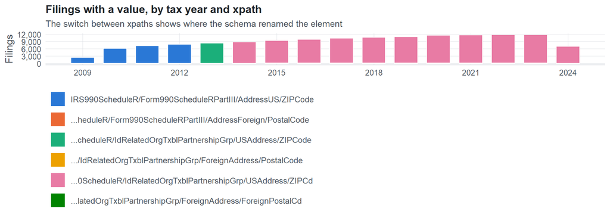

**Table view**

Table view: filings by tax year and series

| Tax year | IRS990ScheduleR/Form990ScheduleRPartIII/AddressUS/ZIPCode | …heduleR/Form990ScheduleRPartIII/AddressForeign/PostalCode | …cheduleR/IdRelatedOrgTxblPartnershipGrp/USAddress/ZIPCode | …/IdRelatedOrgTxblPartnershipGrp/ForeignAddress/PostalCode | …0ScheduleR/IdRelatedOrgTxblPartnershipGrp/USAddress/ZIPCd | …latedOrgTxblPartnershipGrp/ForeignAddress/ForeignPostalCd |
| --- | --- | --- | --- | --- | --- | --- |
| 2009 | 2,408 | 12 | 0 | 0 | 0 | 0 |
| 2010 | 6,092 | 39 | 0 | 0 | 0 | 0 |
| 2011 | 7,239 | 41 | 0 | 0 | 0 | 0 |
| 2012 | 7,721 | 50 | 0 | 0 | 0 | 0 |
| 2013 | 0 | 0 | 8,258 | 61 | 0 | 0 |
| 2014 | 0 | 0 | 0 | 0 | 8,789 | 52 |
| 2015 | 0 | 0 | 0 | 0 | 9,294 | 102 |
| 2016 | 0 | 0 | 0 | 0 | 9,719 | 110 |
| 2017 | 0 | 0 | 0 | 0 | 10,305 | 102 |
| 2018 | 0 | 0 | 0 | 0 | 10,609 | 109 |
| 2019 | 0 | 0 | 0 | 0 | 10,877 | 119 |
| 2020 | 0 | 0 | 0 | 0 | 11,397 | 136 |
| 2021 | 0 | 0 | 0 | 0 | 11,570 | 148 |
| 2022 | 0 | 0 | 0 | 0 | 11,667 | 164 |
| 2023 | 0 | 0 | 0 | 0 | 11,569 | 180 |
| 2024 | 0 | 0 | 0 | 0 | 6,909 | 74 |

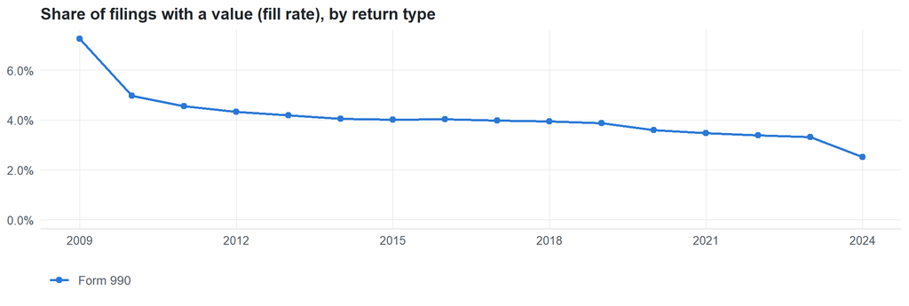

**Table view**

Table view: fill rate

| Tax year | Return type | Filings | All filings | Fill rate |
| --- | --- | --- | --- | --- |
| 2009 | Form 990 | 2,420 | 33,311 | 7.26% |
| 2010 | Form 990 | 6,131 | 123,025 | 4.98% |
| 2011 | Form 990 | 7,280 | 159,504 | 4.56% |
| 2012 | Form 990 | 7,771 | 179,688 | 4.32% |
| 2013 | Form 990 | 8,319 | 198,855 | 4.18% |
| 2014 | Form 990 | 8,841 | 218,619 | 4.04% |
| 2015 | Form 990 | 9,396 | 233,519 | 4.02% |
| 2016 | Form 990 | 9,829 | 243,903 | 4.03% |
| 2017 | Form 990 | 10,407 | 261,612 | 3.98% |
| 2018 | Form 990 | 10,718 | 271,442 | 3.95% |
| 2019 | Form 990 | 10,996 | 283,694 | 3.88% |
| 2020 | Form 990 | 11,533 | 320,342 | 3.60% |
| 2021 | Form 990 | 11,718 | 336,480 | 3.48% |
| 2022 | Form 990 | 11,831 | 349,055 | 3.39% |
| 2023 | Form 990 | 11,749 | 354,768 | 3.31% |
| 2024 | Form 990 | 6,983 | 277,298 | 2.52% |

## Repeating groups

Table cardinality in the concordance: **many**. 6 of 6 observed xpaths repeat within a filing.

Repeating element each xpath was observed in (from the raw indexed xpath)

| Xpath | Repeating element | Filings (summed over years) |
| --- | --- | --- |
| IRS990ScheduleR/Form990ScheduleRPartIII/AddressForeign/PostalCode | (none) | 30 |
| IRS990ScheduleR/Form990ScheduleRPartIII/AddressForeign/PostalCode | IRS990ScheduleR/Form990ScheduleRPartIII | 112 |
| IRS990ScheduleR/Form990ScheduleRPartIII/AddressUS/ZIPCode | (none) | 8148 |
| IRS990ScheduleR/Form990ScheduleRPartIII/AddressUS/ZIPCode | IRS990ScheduleR/Form990ScheduleRPartIII | 15312 |
| IRS990ScheduleR/IdRelatedOrgTxblPartnershipGrp/ForeignAddress/PostalCode | (none) | 19 |
| IRS990ScheduleR/IdRelatedOrgTxblPartnershipGrp/ForeignAddress/PostalCode | IRS990ScheduleR/IdRelatedOrgTxblPartnershipGrp | 42 |
| IRS990ScheduleR/IdRelatedOrgTxblPartnershipGrp/USAddress/ZIPCode | (none) | 2857 |
| IRS990ScheduleR/IdRelatedOrgTxblPartnershipGrp/USAddress/ZIPCode | IRS990ScheduleR/IdRelatedOrgTxblPartnershipGrp | 5401 |
| IRS990ScheduleR/IdRelatedOrgTxblPartnershipGrp/ForeignAddress/ForeignPostalCd | (none) | 157 |
| IRS990ScheduleR/IdRelatedOrgTxblPartnershipGrp/ForeignAddress/ForeignPostalCd | IRS990ScheduleR/IdRelatedOrgTxblPartnershipGrp | 1139 |
| IRS990ScheduleR/IdRelatedOrgTxblPartnershipGrp/USAddress/ZIPCd | (none) | 37222 |
| IRS990ScheduleR/IdRelatedOrgTxblPartnershipGrp/USAddress/ZIPCd | IRS990ScheduleR/IdRelatedOrgTxblPartnershipGrp | 75483 |

## Values

| Result | Check | Detail |
| --- | --- | --- |
| ✓ pass | Values have the ZIP format | 98.7% of values match ^(99999\|999999999\|99999-9999)$ |
| ✓ pass | Stored as text | data type is text |
| ✓ pass | No placeholder values | no all-zero / all-nine placeholders among the most common values |
| ⓘ info | Leading zeros present | at least 1% of values start with 0 in some year, so numeric storage would change them |

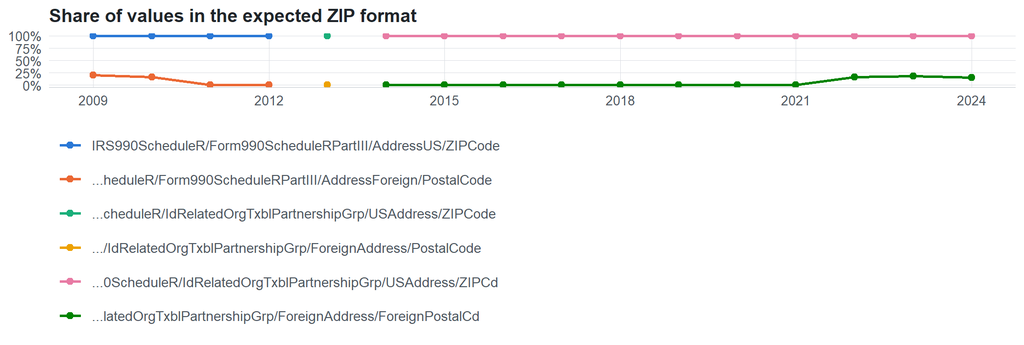

Value shapes (9 = digit, A = letter)

| Series | Shape | Expected | Filings |
| --- | --- | --- | --- |
| IRS990ScheduleR/Form990ScheduleRPartIII/AddressUS/ZIPCode | 99999 | yes | 22,814 |
| IRS990ScheduleR/Form990ScheduleRPartIII/AddressUS/ZIPCode | 999999999 | yes | 2,419 |
| …heduleR/Form990ScheduleRPartIII/AddressForeign/PostalCode | AA9 9AA | no | 62 |
| …heduleR/Form990ScheduleRPartIII/AddressForeign/PostalCode | AA9-9999 | no | 45 |
| …heduleR/Form990ScheduleRPartIII/AddressForeign/PostalCode | 9999 AA | no | 44 |
| …heduleR/Form990ScheduleRPartIII/AddressForeign/PostalCode | 99999-999 | no | 24 |
| …heduleR/Form990ScheduleRPartIII/AddressForeign/PostalCode | A9A 9A9 | no | 20 |
| …heduleR/Form990ScheduleRPartIII/AddressForeign/PostalCode | 999999 | no | 20 |
| …heduleR/Form990ScheduleRPartIII/AddressForeign/PostalCode | AAA 9999 | no | 17 |
| …heduleR/Form990ScheduleRPartIII/AddressForeign/PostalCode | 99999 | yes | 10 |
| …heduleR/Form990ScheduleRPartIII/AddressForeign/PostalCode | 999-9999 | no | 4 |
| …heduleR/Form990ScheduleRPartIII/AddressForeign/PostalCode | A9A 9AA | no | 2 |
| …cheduleR/IdRelatedOrgTxblPartnershipGrp/USAddress/ZIPCode | 99999 | yes | 8,033 |
| …cheduleR/IdRelatedOrgTxblPartnershipGrp/USAddress/ZIPCode | 999999999 | yes | 720 |
| …/IdRelatedOrgTxblPartnershipGrp/ForeignAddress/PostalCode | AA9 9AA | no | 23 |
| …/IdRelatedOrgTxblPartnershipGrp/ForeignAddress/PostalCode | AA9-9999 | no | 23 |
| …/IdRelatedOrgTxblPartnershipGrp/ForeignAddress/PostalCode | A9A 9A9 | no | 20 |
| …/IdRelatedOrgTxblPartnershipGrp/ForeignAddress/PostalCode | 9999 AA | no | 18 |
| …/IdRelatedOrgTxblPartnershipGrp/ForeignAddress/PostalCode | 99999-999 | no | 17 |
| …0ScheduleR/IdRelatedOrgTxblPartnershipGrp/USAddress/ZIPCd | 99999 | yes | 110,352 |
| …0ScheduleR/IdRelatedOrgTxblPartnershipGrp/USAddress/ZIPCd | 999999999 | yes | 9,140 |
| …latedOrgTxblPartnershipGrp/ForeignAddress/ForeignPostalCd | AA9-9999 | no | 595 |
| …latedOrgTxblPartnershipGrp/ForeignAddress/ForeignPostalCd | AA9 9AA | no | 412 |
| …latedOrgTxblPartnershipGrp/ForeignAddress/ForeignPostalCd | A9A9A9 | no | 302 |
| …latedOrgTxblPartnershipGrp/ForeignAddress/ForeignPostalCd | 999999 | no | 137 |
| …latedOrgTxblPartnershipGrp/ForeignAddress/ForeignPostalCd | 99999-999 | no | 106 |
| …latedOrgTxblPartnershipGrp/ForeignAddress/ForeignPostalCd | 99999 | yes | 82 |
| …latedOrgTxblPartnershipGrp/ForeignAddress/ForeignPostalCd | A9A 9A9 | no | 56 |
| …latedOrgTxblPartnershipGrp/ForeignAddress/ForeignPostalCd | A9A 9AA | no | 48 |
| …latedOrgTxblPartnershipGrp/ForeignAddress/ForeignPostalCd | AA 99 | no | 27 |
| …latedOrgTxblPartnershipGrp/ForeignAddress/ForeignPostalCd | A9 9AA | no | 26 |
| …latedOrgTxblPartnershipGrp/ForeignAddress/ForeignPostalCd | AA99999 | no | 16 |
| …latedOrgTxblPartnershipGrp/ForeignAddress/ForeignPostalCd | 9999 AA | no | 15 |
| …latedOrgTxblPartnershipGrp/ForeignAddress/ForeignPostalCd | AA9 9999 | no | 15 |

## Examples

| Tax year | Return | Xpath | Organization | Value | Source |
| --- | --- | --- | --- | --- | --- |
| 2024 | 990 | IRS990ScheduleR/IdRelatedOrgTxblPartnershipGrp/ForeignAddress/ForeignPostalCd | McMaster University | L8P 0A1 | [XML](https://gt990datalake-rawdata.s3.amazonaws.com/EfileData/XmlFiles/202620709349301752_public.xml) |
| 2024 | 990 | IRS990ScheduleR/IdRelatedOrgTxblPartnershipGrp/USAddress/ZIPCd | NEIGHBORHOOD DEVELOPMENT CENTER INC | 55104 | [XML](https://gt990datalake-rawdata.s3.amazonaws.com/EfileData/XmlFiles/202532339349300338_public.xml) |
| 2023 | 990 | IRS990ScheduleR/IdRelatedOrgTxblPartnershipGrp/ForeignAddress/ForeignPostalCd | THE FULLER FOUNDATION | KY1-9005 | [XML](https://gt990datalake-rawdata.s3.amazonaws.com/EfileData/XmlFiles/202403169349306145_public.xml) |
| 2023 | 990 | IRS990ScheduleR/IdRelatedOrgTxblPartnershipGrp/USAddress/ZIPCd | Neurology Associates of Stony Brook University Faculty Practice Corp | 11790 | [XML](https://gt990datalake-rawdata.s3.amazonaws.com/EfileData/XmlFiles/202531339349306648_public.xml) |
| 2022 | 990 | IRS990ScheduleR/IdRelatedOrgTxblPartnershipGrp/ForeignAddress/ForeignPostalCd | DUKE MEDICINE GLOBAL SUPPORT CORPORATION | EH3 9WJ | [XML](https://gt990datalake-rawdata.s3.amazonaws.com/EfileData/XmlFiles/202431359349305623_public.xml) |
| 2022 | 990 | IRS990ScheduleR/IdRelatedOrgTxblPartnershipGrp/USAddress/ZIPCd | Alexian Brothers - AHS Midwest Region Health Co | 60007 | [XML](https://gt990datalake-rawdata.s3.amazonaws.com/EfileData/XmlFiles/202401369349308605_public.xml) |
| 2021 | 990 | IRS990ScheduleR/IdRelatedOrgTxblPartnershipGrp/ForeignAddress/ForeignPostalCd | THE LORD FOUNDATION OF NORTH CAROLINA | EH3 9WJ | [XML](https://gt990datalake-rawdata.s3.amazonaws.com/EfileData/XmlFiles/202331299349302508_public.xml) |
| 2021 | 990 | IRS990ScheduleR/IdRelatedOrgTxblPartnershipGrp/USAddress/ZIPCd | Methodist-CDI | 66211 | [XML](https://gt990datalake-rawdata.s3.amazonaws.com/EfileData/XmlFiles/202233199349316433_public.xml) |
| 2020 | 990 | IRS990ScheduleR/IdRelatedOrgTxblPartnershipGrp/ForeignAddress/ForeignPostalCd | Harvard Real Estate - Allston Inc | KY11104 | [XML](https://gt990datalake-rawdata.s3.amazonaws.com/EfileData/XmlFiles/202231339349309208_public.xml) |
| 2020 | 990 | IRS990ScheduleR/IdRelatedOrgTxblPartnershipGrp/USAddress/ZIPCd | Southeast Volusia Healthcare Corporation | 27615 | [XML](https://gt990datalake-rawdata.s3.amazonaws.com/EfileData/XmlFiles/202103199349312315_public.xml) |
| 2019 | 990 | IRS990ScheduleR/IdRelatedOrgTxblPartnershipGrp/ForeignAddress/ForeignPostalCd | CLINICAL CARE ASSOCIATES OF THE | KY1-9009 | [XML](https://gt990datalake-rawdata.s3.amazonaws.com/EfileData/XmlFiles/202101339349302155_public.xml) |
| 2019 | 990 | IRS990ScheduleR/IdRelatedOrgTxblPartnershipGrp/USAddress/ZIPCd | SOUTHFIELD NON-PROFIT HOUSING CORP | 48033 | [XML](https://gt990datalake-rawdata.s3.amazonaws.com/EfileData/XmlFiles/202013169349303486_public.xml) |

## Reviewer checklist

- The definition matches the form line and instructions for every xpath’s schema years.
- Every xpath pooled here measures the same thing on the 990 and 990-EZ (close enough for analysis).
- The coverage chart has no unexplained gaps or jumps between tax years.
- Each open flag is fixed, or accepted with a note in validation_log.csv.
- The data type is text so leading zeros and letters survive.
- The identifier belongs to the entity the variable names (the filer, preparer, related organization…).
- Formats with and without punctuation (e.g. ZIP+4, dashes) are normalized consistently downstream.

Record the review as a row in `inst/extdata/src/validation_log.csv` (variable_name, reviewer, date, status, note). Evidence built 2026-09-23 17:09:04 MST from the ef2 DuckDB builds (tax years 2009–2024).